# assignment 9

Samantha Barber

2022-11-22

## Time Perception

This is my personal data that I gathered from people ages 3-62. I measured their heart rate, age, and the time they felt was 1 minute. The graph below is a quick look at our data showing as age increases, so does the perception of 1 minute.

I also added a model to summarize our experiment. We found that on average every year we get older our perception of 1 minute increases by 0.86 seconds, our Pvalue also suggests that age is a significant factor in time perception.

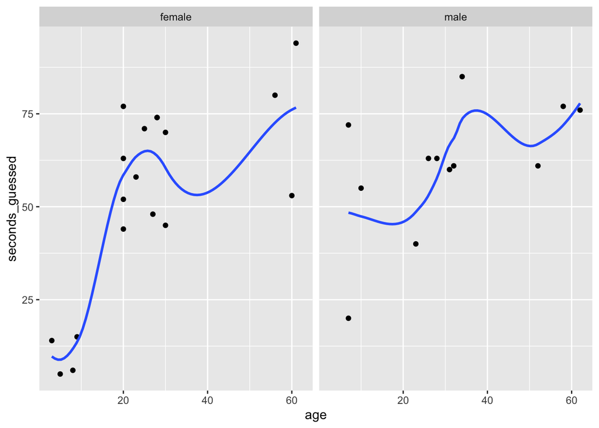

```
##
## Call:
## glm(formula = seconds_guessed ~ age, data = dat)
##
## Deviance Residuals:
##     Min       1Q   Median       3Q      Max
## -32.443  -12.247    1.686   13.738   34.424
##
## Coefficients:
##             Estimate Std. Error t value Pr(>|t|)
## (Intercept)  31.5076     6.3468   4.964 3.06e-05 ***
## age           0.8669     0.1922   4.511 0.000105 ***
## ---
## Signif. codes:  0 '***' 0.001 '**' 0.01 '*' 0.05 '.' 0.1 ' ' 1
##
## (Dispersion parameter for gaussian family taken to be 333.7562)
##
##     Null deviance: 16137.5  on 29  degrees of freedom
## Residual deviance:  9345.2  on 28  degrees of freedom
## AIC: 263.38
##
## Number of Fisher Scoring iterations: 2
```

## Older participants.

It was thought that the older we get, the faster time goes by for us. Below is a graph of participants that I measured 30 years and older to determine if the majority of these participants perceived a minute to be longer than 60 seconds.

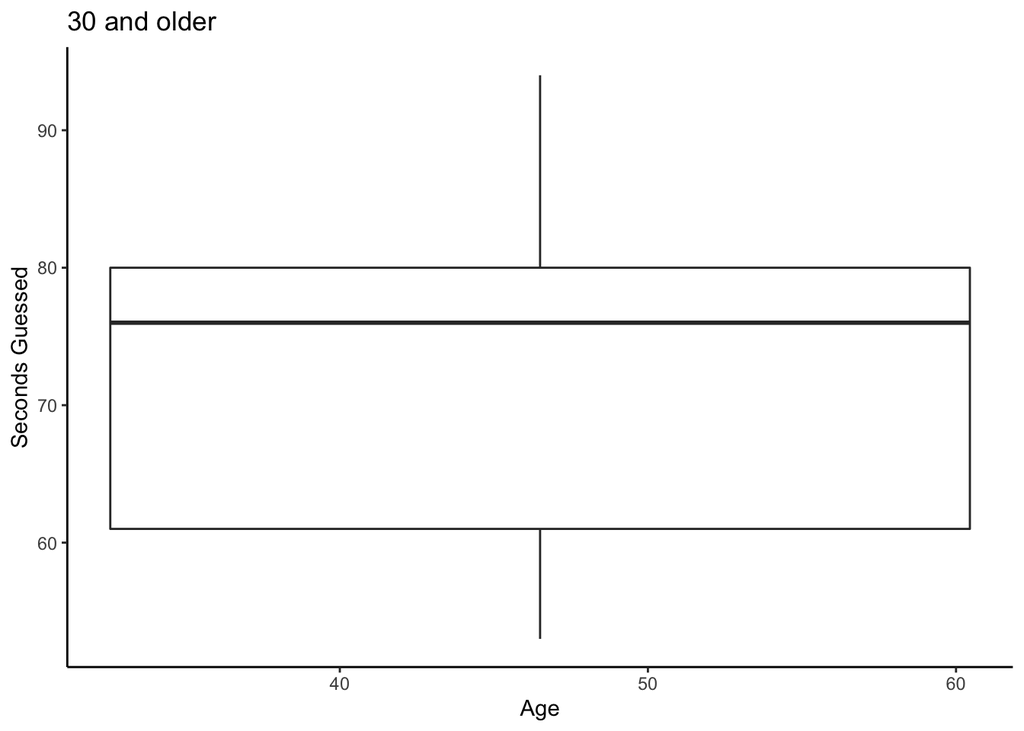

The majority of guesses were well over 60 seconds! lets see how this measures against the younger group of participants.

## Younger Participants

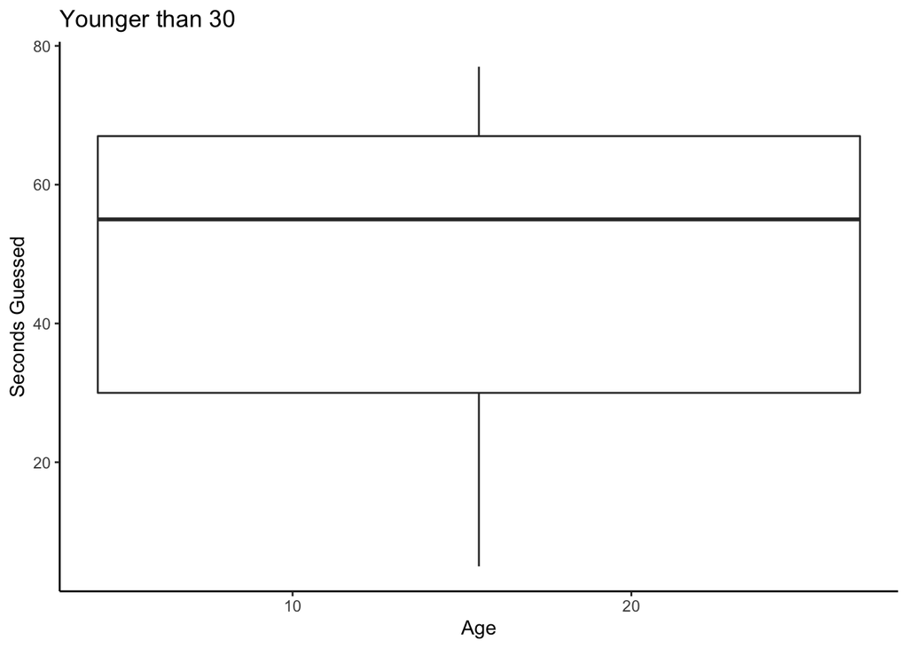

In this graph, the kids who are younger than 30, mostly measured below 60 seconds. Following our idea that time moves quickly the older we get, and slowly the younger we are.

Not only did we measure time, but heart rate to see if it had any effect on peoples perception of time.

```
##             Df Sum Sq Mean Sq F value   Pr(>F)
## age          1   6792    6792  22.094 6.81e-05 ***
## heart_rate   1   1045    1045   3.398   0.0763 .
## Residuals   27   8300     307
## ---
## Signif. codes:  0 '***' 0.001 '**' 0.01 '*' 0.05 '.' 0.1 ' ' 1
```

accoding to this model, we see age is significant to the guesses, but heart rate is not significant. In the next model, we will combine heart rate and age, and see how they affect eachother.

```
##                Df Sum Sq Mean Sq F value   Pr(>F)
## age             1   6792    6792  26.125 2.51e-05 ***
## heart_rate      1   1045    1045   4.018   0.0555 .
## age:heart_rate  1   1541    1541   5.925   0.0221 *
## Residuals      26   6760     260
## ---
## Signif. codes:  0 '***' 0.001 '**' 0.01 '*' 0.05 '.' 0.1 ' ' 1
```

This model is showing one star next to the combination of age and heart rate, but still not as significant as age alone on this experiment.

## conclusion

here is a link https://www.scientificamerican.com/article/why-does-time-seem-to-speed-up-with-age/ to an article about age and time perception.